# Graphical options with `plot`

In this section we show how to plot different graphics with the `plot` function. A complete description can be viewed through `?plot.fullsib_scan`. As an example we will use the example data from the package:

As an example we will use the example data from the package, the below step are described at the *`fullsibQTL` Tutorial* vignette.

```r
  library( "fullsibQTL" )
  data( "example_QTLfullsib" )
  fullsib <- create_fullsib( example_QTLfullsib,
                             list( LG1_final, LG2_final, LG3_final, LG4_final ),
                             step = 1,
                             map.function = "kosambi",
                             condIndex = 3.5 )

  ## IM
  im <- im_scan( fullsib )
  qtls.im <- r2_ls( fullsib,
                    pheno.col = 1,
                    lg = c( 1, 1, 2, 2, 2, 3, 3, 4 ),
                    pos = c( "loc13", "M12", "loc45", "loc77", "loc108", "M33", "loc65", "M52" ) )

  ## CIM
  cofs.fs <- cof_selection( fullsib,
                            pheno.col = 1,
                            k=log(300),
                            n.cofactor = 10)
  cim <- cim_scan( cofs.fs )
  qtls.cim <- r2_ls( fullsib,
                     pheno.col = 1,
                     lg = c( 1, 1, 2, 2, 2, 3, 3, 4 ),
                     pos = c( "loc13", "M12", "loc45", "loc77", "loc108", "M33", "loc65", "M52" ) )

  ## Getting im and cim peaks for alpha 0.05.
  im.peak1 <- summary( im_perm, alpha = 0.05 )[ 1, 1 ]
  im.peak2 <- summary( im_perm, alpha = 0.05 )[ 1, 2 ]

  cim.peak1 <- summary( cim_perm, alpha = 0.05 )[ 1, 1 ]
  cim.peak2 <- summary( cim_perm, alpha = 0.05 )[ 1, 2 ]
```

To plot the basic graphic

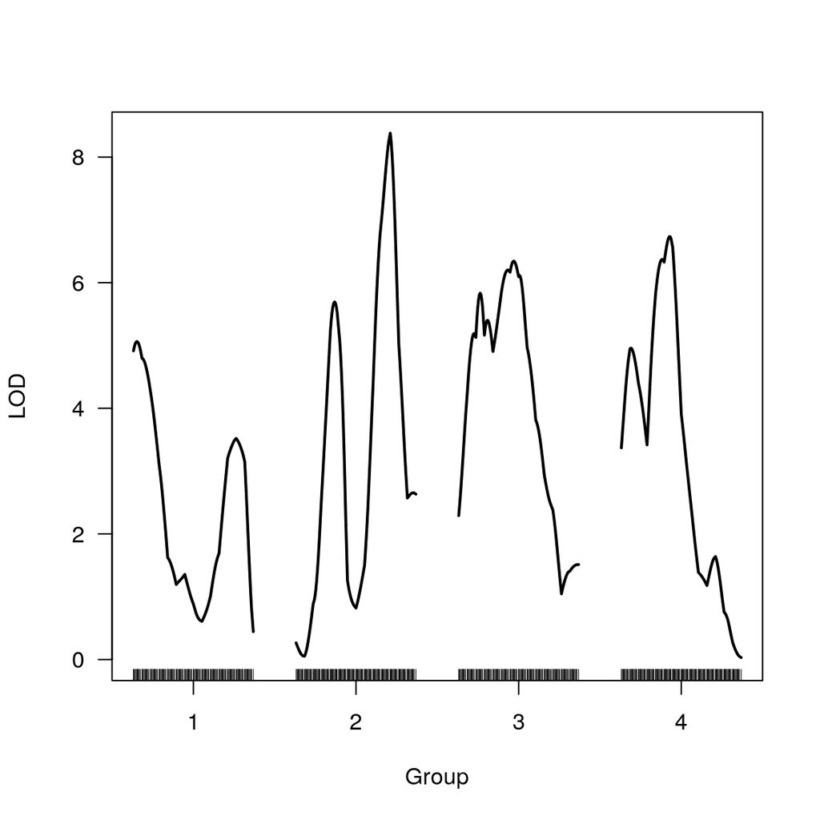

```r
plot( im )
```

## Customizing Graphics

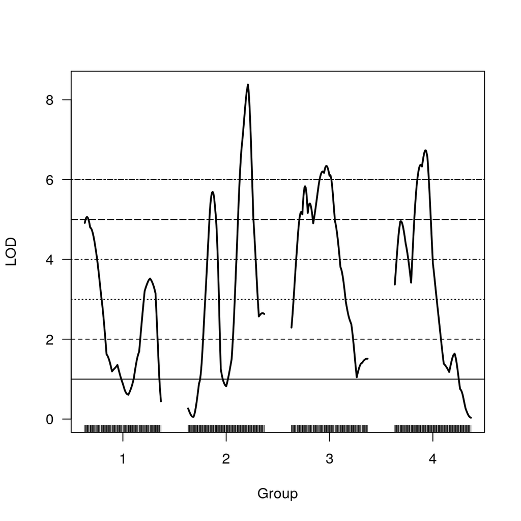

```r
## argument lty
## Changes the line type
## There are 6 different line types as follow:
plot( im )
abline( h = c( 1, 2, 3, 4, 5, 6 ), lty = c ( 1, 2, 3, 4, 5, 6 ) )
```

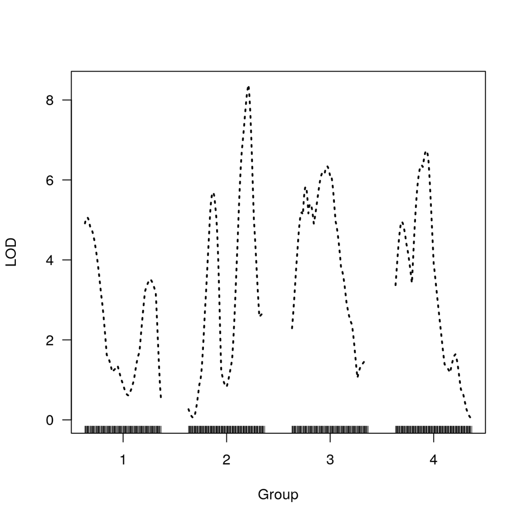

```r
## argument lwd
### changes the line width. It changes in a relative proportion to
### the default. 2 is twice the default width, 3 is triple of the
### default, and so on.

## You can set any of them with the plot:
plot( im, lty = 3, lwd = 2 )
```

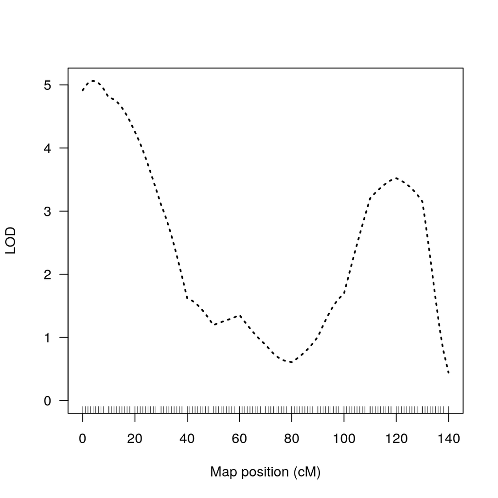

```r
## argument lg
### selects which LG to plot
## Plotting just LG1
plot( im, lty = 3, lwd = 2, lg = 1 )
```

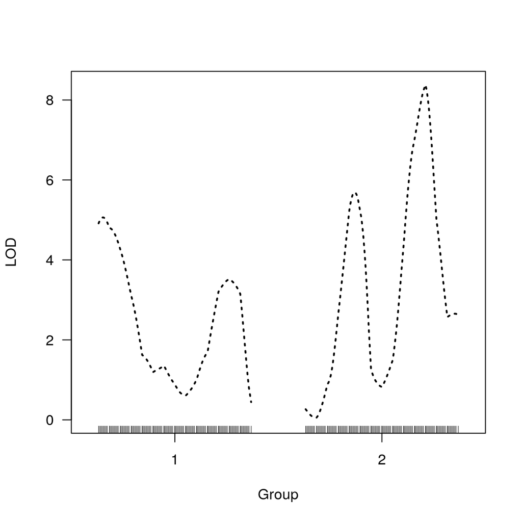

```r
## Plotting LG1 and LG2
plot( im, lty=3, lwd = 2, lg = c ( 1 , 2 ) )
```

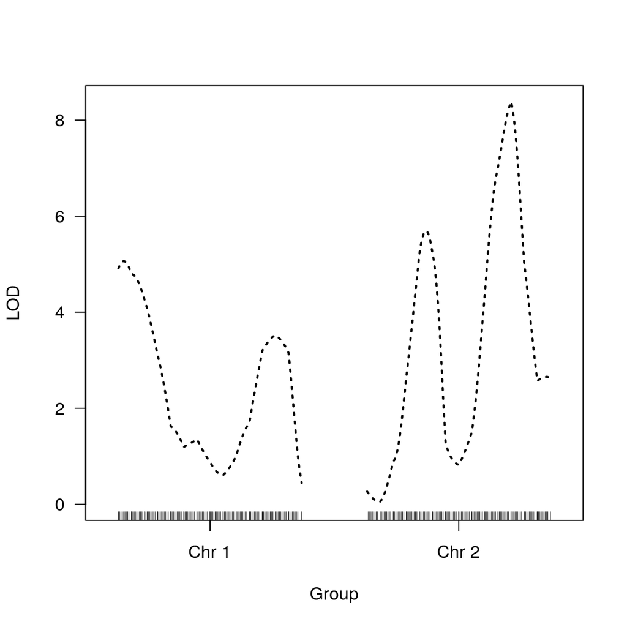

```r
## argument label.lg
### labels the LGs
plot( im, lty = 3, lwd = 2, lg = c( 1, 2 ),
      label.lg = c( "Chr 1", "Chr 2" ) )
```

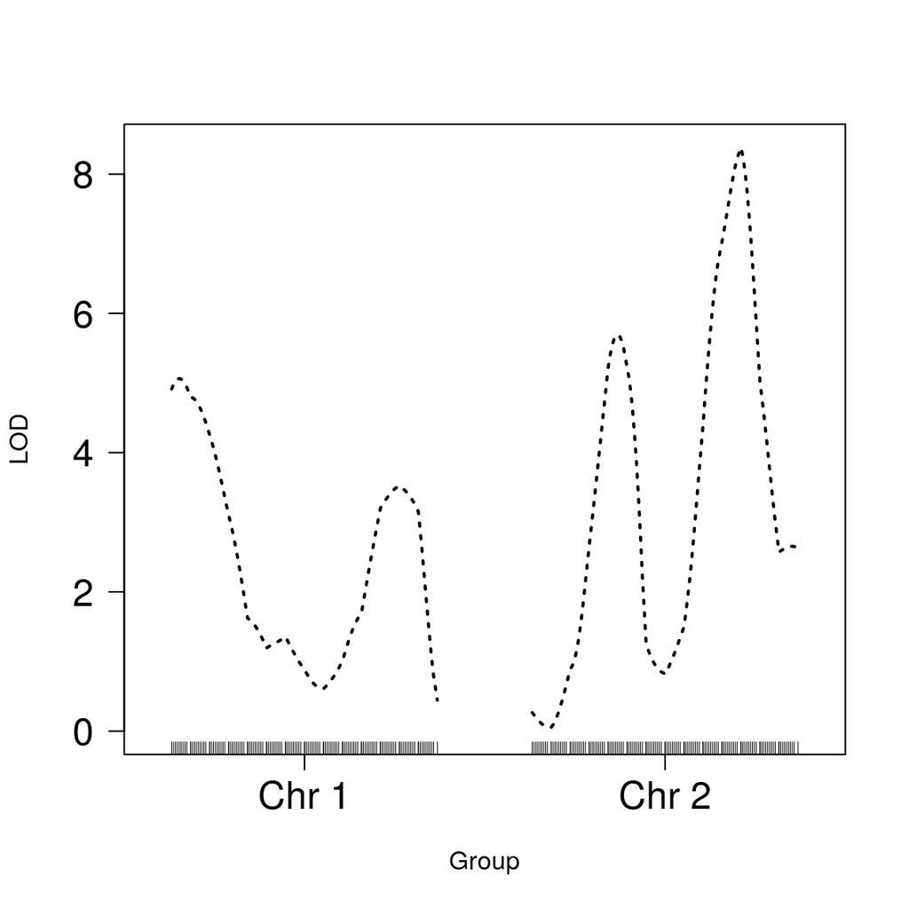

```r
## argument cex.axis
### changes the magnification of axis annotation relative to cex
plot( im, lty = 3, lwd = 2, lg = c( 1, 2 ),
      label.lg = c( "Chr 1", "Chr 2" ), cex.axis = 1 )
plot( im, lty = 3, lwd = 2, lg = c( 1, 2 ),
      label.lg = c("Chr 1","Chr 2"), cex.axis = 1.5 )
```

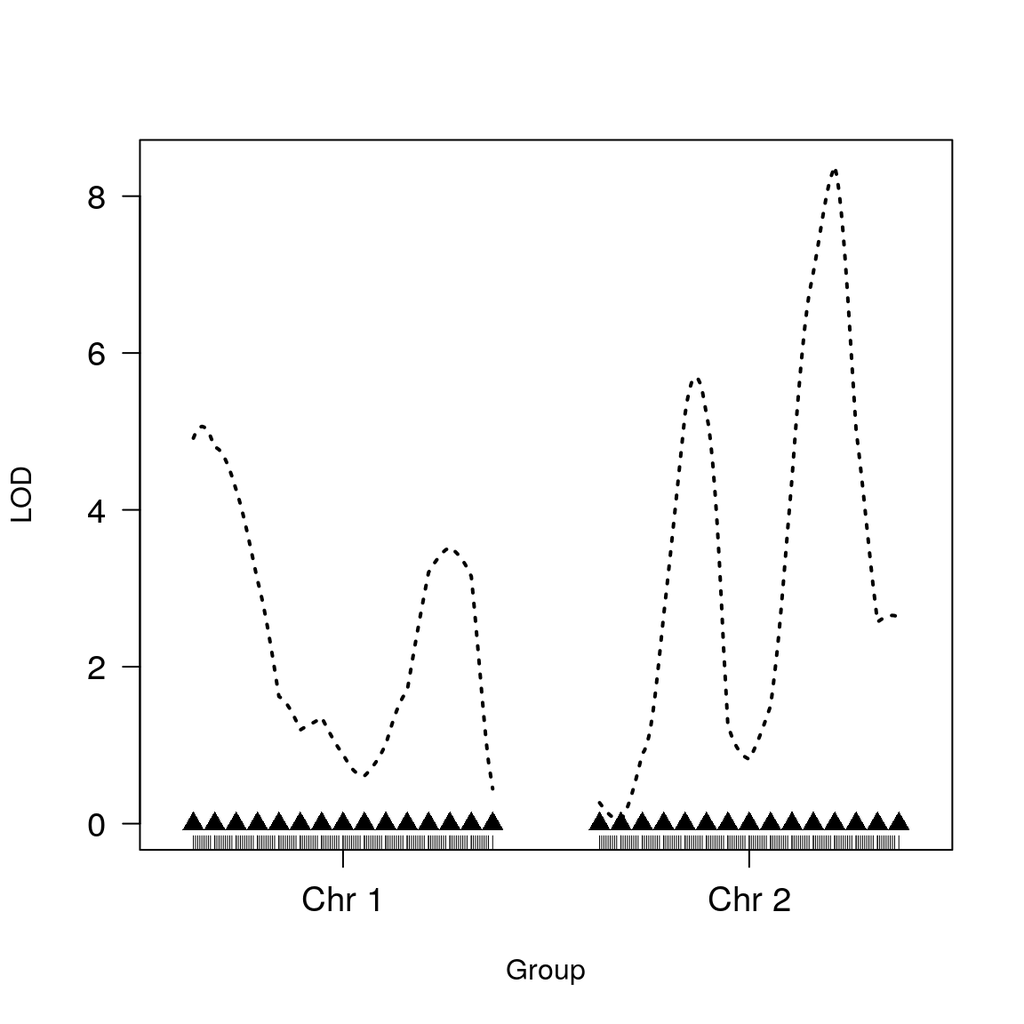

```r
## argument incl.mkr
### includes the marker position there are 3 options:
### `points`, `name`, and, `none`. `none` is default.
plot( im, lty = 3, lwd = 2, lg = c( 1, 2 ),
      label.lg = c( "Chr 1", "Chr 2" ), cex.axis = 1.2,
      incl.mkr = "points" )
```

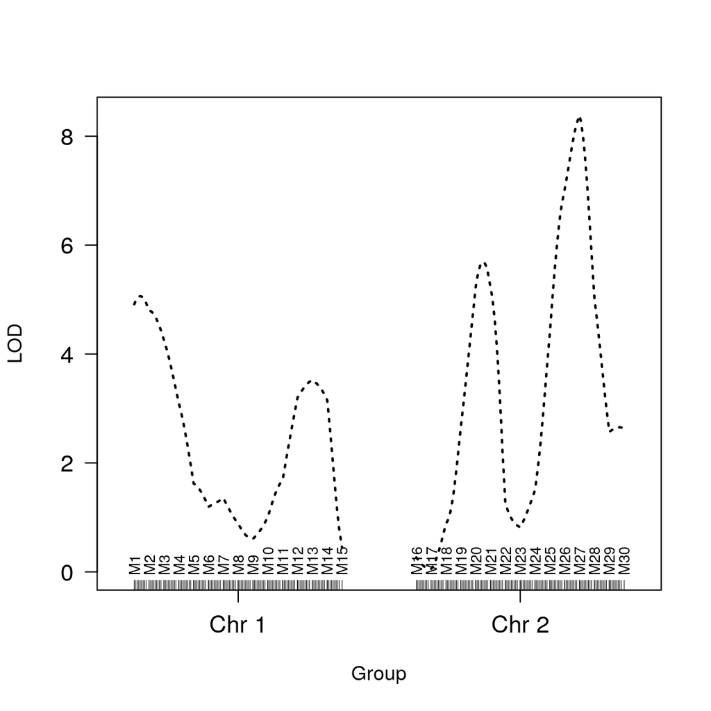

```r
## argument cex.incl
### changes the magnification of incl.mrk annotation
### relative to cex.
plot( im, lty = 3, lwd = 2, lg = c( 1, 2 ),
      label.lg = c( "Chr 1", "Chr 2" ), cex.axis = 1.2,
      incl.mkr = "name", cex.incl = .75 )
```

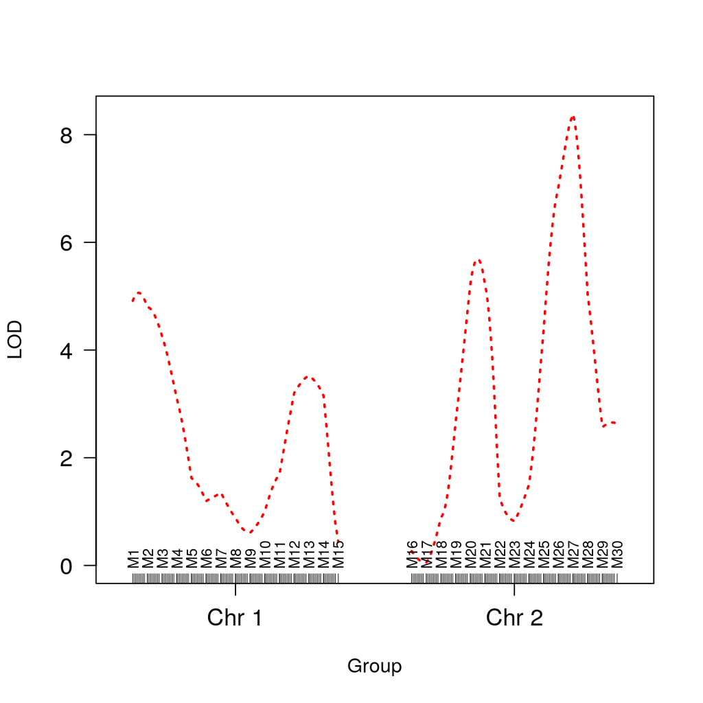

```r
## argument gap
### enlarges the gap between chromosomes (in CM)
plot( im, lty = 3, lwd = 2, lg = c( 1, 2 ),
      label.lg = c( "Chr 1", "Chr 2" ), cex.axis = 1.2,
      incl.mkr = "name", cex.incl = .75, gap = 50 )

## argument col
### changes the line colors
plot( im, lty = 3, lwd = 2, lg = c( 1, 2 ),
      label.lg = c( "Chr 1", "Chr 2" ), cex.axis = 1.2,
      incl.mkr = "name", cex.incl = .75, gap = 50, col="red")
```

You can check more colors options at this [cheatsheet](https://www.nceas.ucsb.edu/~frazier/RSpatialGuides/colorPaletteCheatsheet.pdf) or at this color [guide](http://www.stat.columbia.edu/~tzheng/files/Rcolor.pdf)

You can also customize the plot with the default R `plot.default` options as `main`, `ylab`, `xlab`, `yaxt`, `ylim`, etc.

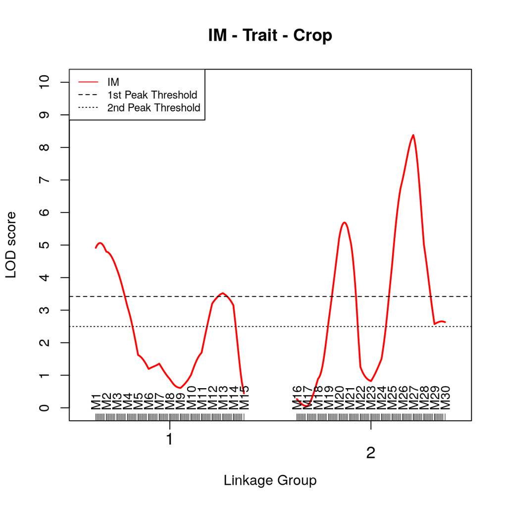

```r
plot( im, lty=1, lwd=2, lg=c(1,2), cex.axis=1.2,
      incl.mkr="name", cex.incl = .9, gap = 50, col="red",
      alternate.lgid = TRUE,
      ## Configuring with R plot options:
      main = "IM - Trait - Crop",
      xlab = "Linkage Group",
      ylab = "LOD score",
      yaxt = "n",
      ylim = c(0,10))
axis( side = 2, at = seq( 0, 10, 1 ), lwd = 1 )
abline( h = im.peak1, lty = 2 )
abline( h = im.peak2, lty = 3 )
legend( "topleft", lty = c( 1, 2, 3, 0 ), cex = 0.75,
        col = c( "red", "black", "black" ),
        legend = c( "IM", "1st Peak Threshold", "2nd Peak Threshold" ) )
```

## Graphical comparision between `(c)im_scan`

The IM and CIM mapping results can be compared in a graphical way with the following codes:

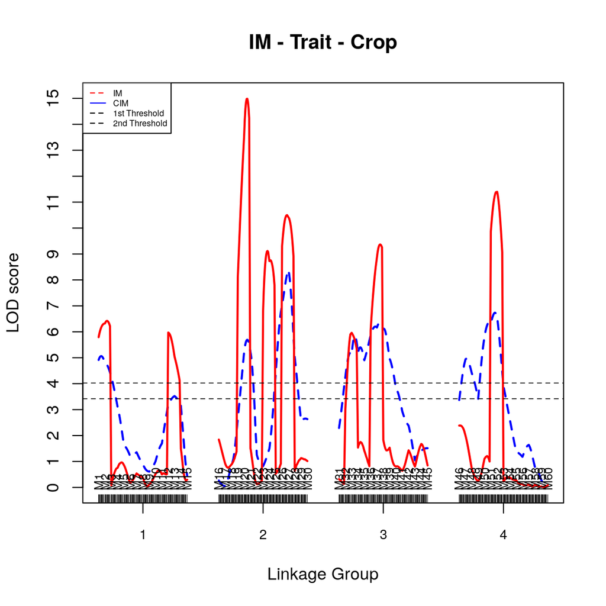

```r
plot( im,cim, lty = c(2,1), lwd = 2, incl.mkr = "name",
      cex.incl = 0.7, gap = 50, cex.axis = 0.8,
      col = c("blue","red"),
      main = "IM - Trait - Crop",
      xlab = "Linkage Group",
      ylab = "LOD score",
      yaxt = "n",
      ylim = c( 0, 15 ) )
axis( side = 2, at = seq( 0, 15, 1 ), lwd = 1 )
abline( h = im.peak1, lty = 2, lwd = 0.75 )
abline( h = cim.peak1, lty = 2, lwd = 0.75 )
legend( "topleft", lty = c( 2, 1, 2, 2 ), cex = 0.5,
        col = c( "red", "blue", "black", "black" ),
        legend = c( "IM", "CIM", "1st Threshold","2nd Threshold") )
```

## Adding QTL location to the graphic

Our QTLs are the same ones of the *`fullsibQTL` Tutorial* vignette as follows:

```r
print( cim, lg = 1, pos = c( "loc13", "M12" ) )
```

```
#>       lg pos.cM      LOD model
#> loc13  1     13 6.420684     0
#> M12    1    110 5.970667     0
```

```r
print( cim, lg = 2, pos = c( "loc45", "loc77" ,"loc108" ) )
```

```
#>        lg pos.cM       LOD model
#> loc45   2     45 14.985451     0
#> loc77   2     77  9.115538     0
#> loc108  2    108 10.496445     0
```

```r
print( cim, lg = 3, pos = c( "M33", "loc65" ) )
```

```
#>       lg pos.cM      LOD model
#> M33    3     20 5.960747     0
#> loc65  3     65 9.367385     0
```

```r
print( cim, lg = 4, pos = "M52" )
```

```
#>     lg pos.cM      LOD model
#> M52  4     60 11.39792     0
```

The `plot` function is not so straighforward to add QTL location as the `plot_fullsibQTL` function. Here, to add them to the graphic we can use the function `points` as follows. Knowing that the `gap` space is `50`, we can add this to the total size of each LG and get the position. The points will be localized at:

```r
points.loc <- c( 13, 110, 45, 77, 108, 20, 65, 60 )
points.loc <- points.loc + c( 0, 0,
                              140 + 50, 140 + 50, 140 + 50,
                              140 + 50 + 140 + 50, 140 + 50 + 140 + 50,
                              140 + 50 + 140 + 50 + 140 + 50 )
```

Therefore:

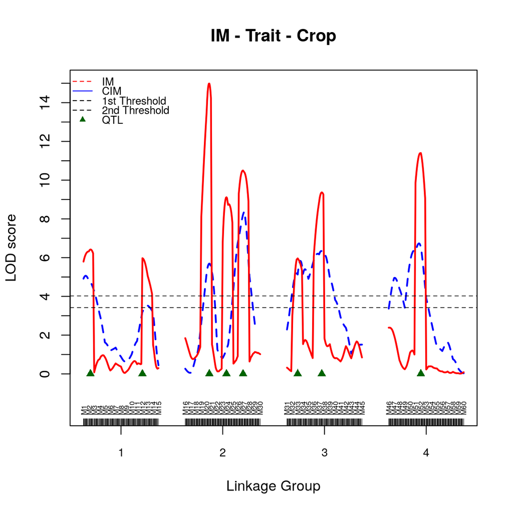

```r
plot( im, cim, lty = c( 2, 1 ), lwd = 2,
      incl.mkr = "name", cex.incl = 0.5, gap = 50,
      cex.axis = 0.8, col = c( "blue", "red" ),
      main = "IM - Trait - Crop",
      xlab = "Linkage Group",
      ylab = "LOD score",
      yaxt = "n",
      ylim = c( -2, 15 ) )
axis( side=2, at = seq( 0, 15, 1 ), lwd = 1 )
abline( h = im.peak1, lty = 2, lwd = 0.75 )
abline( h = cim.peak1, lty = 2, lwd = 0.75 )
points( y = rep( 0, 8 ), x = points.loc, pch = 17, col = "dark green" )
legend( "topleft", lty = c( 2, 1, 2, 2, 0 ), cex = 0.75,
        pch = c( NA, NA, NA, NA, 17 ),
        col = c( "red", "blue", "black", "black", "dark green" ),
        legend = c( "IM", "CIM", "1st Threshold", "2nd Threshold", "QTL"),
        bty = 'n', y.intersp = .75 )
```

[Statistical Genetics Lab](http://statgen.esalq.usp.br)  
Department of Genetics  
Luiz de Queiroz College of Agriculture  
University of São Paulo

2017-08-23